# HW4_DDS_KHenley

# Question 2.C. To make things easier to read, put par(las=2) before your plot to make the text perpendicular to the axis. Make a barplot of major_count. Make sure to label the title with something informative (check the vignette if you need), label the x and y axis, and make it any color other than grey. Assign the major_category labels to their respective bar. Flip the barplot horizontally so that bars extend to the right, not upward. All of these options can be done in a single pass of barplot(). Note: It’s okay if it’s wider than the preview pane.

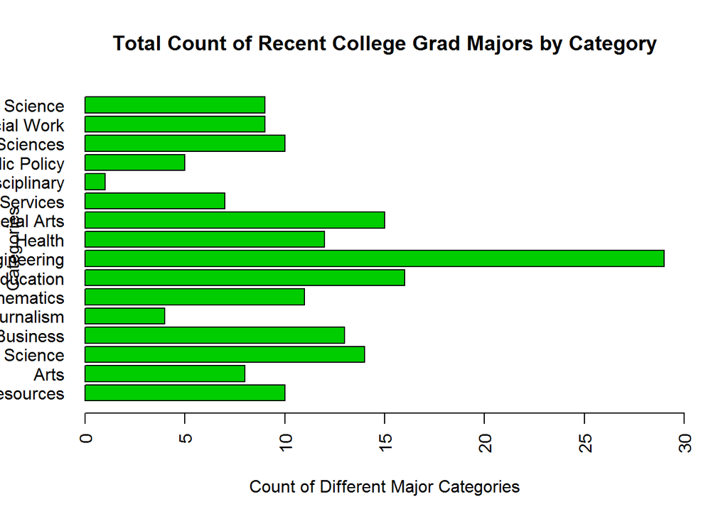

```r
par(las=2)
plotvector <- c(10,8,14,13,4,11,16,29,12,15,7,1,5,10,9,9)
names(plotvector)=c("Agriculture & Natural Resources","Arts","Biology & Life Science","Business","Communications & Journalism","Computers & Mathematics","Education","Engineering","Health","Humanities & Liberal Arts","Industrial Arts & Consumer Services","Interdisciplinary","Law & Public Policy","Physical Sciences","Psychology & Social Work","Social Science")
barplot(plotvector, main="Total Count of Recent College Grad Majors by Category", horiz=TRUE, col=3, xlab="Count of Different Major Categories", ylab="Categories", xlim= c(0,30))
```

# Question 2.D. Write the fivethirtyeight data to a csv file. Make sure that it does not have row labels. (I am going to assume this is meaning to only write the dataset we’ve been working with so far)

```r
write.csv(df, "college_recent_grads18.csv", row.names=F)
```

# Question 3.A. Start a new repository on GitHub for your SMU MSDS homework. On your local device, make sure there is a directory for Homework at the minimum; you are welcome to add whatever you would like to this repo in addition to your requirements here.*created new repo here: https://github.com/kristopher33/SMU_MSDS_HW.git

# code for creating new directory for Homework:

```r
getwd()
```

```
## [1] "C:/Users/henlek1/Desktop/Kris/School/Doing Data Science"
```

```r
dir.create("HW_MSDS_SMU")
```

# Question 3.B.Create a README.md file which explains the purpose of the repository, the topics included, the sources for the material you post, and contact information in case of questions.Remember, the one in the root directory should be general. You are welcome to make short READMEs for each assignment individually in other folders.*This was done directly in GitHub: https://github.com/kristopher33/SMU_MSDS_HW.git

# Question 3.C. In one (or more) of the nested directories, post your RMarkdown script, HTML file, and data from ‘fivethirtyeight.’ Make sure that in your README or elsewhere that you credit fivethirtyeight in some way.All requested files reside at the following path: SMU_MSDS_HW -> HW_MSDS_SMU -> DDS_HW

https://github.com/kristopher33/SMU_MSDS_HW.git